# 2024 NH3-loss Statistical Models, cube root

Maarit Mäenpää + NJH

2026-01-07

## Model A_base

To reduce the number of parameters in the statistical model, we categorised different fertilisers into categories consisting of;

**Urea**: Fertilisers where the main component was urea

**UAN**: UAN

**ammonium+1**: Fertilisers including a low percentage of ammonium

**ammonium+2**: Fertilisers with higher percentage of ammonium

The table below depicts the categorisation of fertilisers, and the number of observations in each sub-category.

```
##   Fertiliser    N
## 1      urea+ 1729
## 2        UAN  128
## 3 ammonium+1  365
## 4 ammonium+2  374
```

In Model A_Base, we examined the effects of application method (Application), measurement method (Method), and location of study (Place) on NH3 emissions. The tables below show the number of observations within each category examined.

```
##    Application    N
## 1    Broadcast 1771
## 2 Incorporated  344
## 3     Injected   14
## 4       Liquid  467
```

```
##                Method    N
## 1            Micromet  205
## 2                 15N    5
## 3      Closed chamber  774
## 4         Drager-Tube  161
## 5           Semi-open  148
## 6 Ventilated chambers 1032
## 7          Windtunnel  271
```

```
##     Place    N
## 1 Outdoor 1411
## 2     Lab 1185
```

Table below shows counts of all categories of variables:

```
##
##                       Outdoor Lab
##   Micromet                205   0
##   15N                       5   0
##   Closed chamber          369 405
##   Drager-Tube             161   0
##   Semi-open               148   0
##   Ventilated chambers     259 773
##   Windtunnel              264   7
```

```
##
##                Outdoor  Lab
##   Broadcast       1031  740
##   Incorporated     148  196
##   Injected          14    0
##   Liquid           218  249
```

```
##
##          Outdoor  Lab
##   Arable     713   17
##   Grass      320   12
##   None       360 1156
##   Other       18    0
```

```
## , ,  = Micromet,  = Outdoor
##
##
##              Broadcast Incorporated Injected Liquid
##   urea+            128            5        0     16
##   UAN                0            0        0     31
##   ammonium+1        20            0        0      0
##   ammonium+2         0            0        0      5
##
## , ,  = 15N,  = Outdoor
##
##
##              Broadcast Incorporated Injected Liquid
##   urea+              5            0        0      0
##   UAN                0            0        0      0
##   ammonium+1         0            0        0      0
##   ammonium+2         0            0        0      0
##
## , ,  = Closed chamber,  = Outdoor
##
##
##              Broadcast Incorporated Injected Liquid
##   urea+            171           33        0     36
##   UAN                0            0        0     39
##   ammonium+1        16            3        0     10
##   ammonium+2        53            6        0      2
##
## , ,  = Drager-Tube,  = Outdoor
##
##
##              Broadcast Incorporated Injected Liquid
##   urea+             78           34        0     36
##   UAN                0            0        0      0
##   ammonium+1         4            6        0      0
##   ammonium+2         3            0        0      0
##
## , ,  = Semi-open,  = Outdoor
##
##
##              Broadcast Incorporated Injected Liquid
```

[output cut: 70 more lines]

```
##
##              Broadcast Incorporated Injected Liquid
##   urea+            312           92        0    129
##   UAN                0            0        0     16
##   ammonium+1        72           33        0      1
##   ammonium+2       110            1        0      7
##
## , ,  = Windtunnel,  = Lab
##
##
##              Broadcast Incorporated Injected Liquid
##   urea+              6            1        0      0
##   UAN                0            0        0      0
##   ammonium+1         0            0        0      0
##   ammonium+2         0            0        0      0
```

We analysed the effects of Fertiliser types (Urea, UAN, ammonium+1, and ammonium+2), Application method (Broadcast, Liquid, Incorporated, and Injected), the measurement method (Micromet, 15N, Closed chamber, Drager-Tube, Semi-open, Ventilated chambers, and Windtunnel), and whether the study was conducted in the field or in the laboratory, using a general linear mixed effects model (lmer, R-package lme4, Bates et al. 2015). Because the observations originated from different studies, each study most often contributing more than one observation, the reference for study was used as a random effect, to account for non-independence due to repeated measurements.

We used NH3-loss (%), calculated as relative difference between ammonia emissions from a test site and a control site proportional to the control, as a response variable. There were 19 negative observations out of the total 2596.

The frequency distribution of the untransformed NH3-loss measurements is shown below.

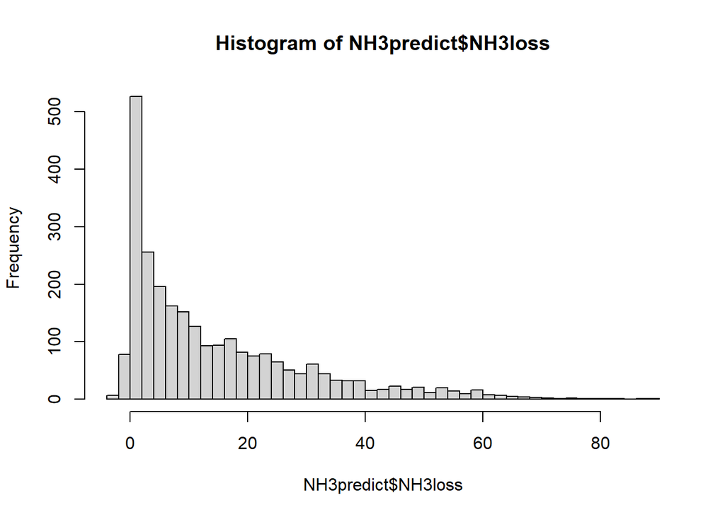

To account for heteroscedasticity, we used weighted ordinary least squares (WOLS, Olvera Astivia & Bruno 2019). We built a vector giving larger weight to observations with smaller variation. To this end, we extracted absolute residuals and fitted values from an unweighted version of Model A_Base (see below for code). We then applied a regression model between the absolute residuals (response variable and fitted values (predictor variable), to estimate the relationship between the amount of variation and the data and the model estimates. To attain a vector with higher values attached to lower variation, we used the inverse of the relationship estimated in the regression model. The weights correspond to increased weight with decrease in variation, thus giving more precedence to more accurate data.

The model assumptions are checked in the figures below:

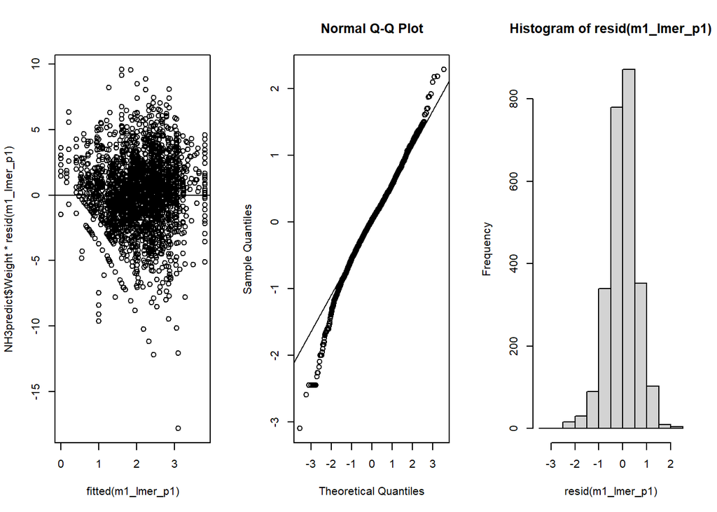

The pairwise-comparisons of factor-level effects can be seen below. The comparisons are made to urea (in Fertiliser), Broadcast (in Application), Micromet (in Method), and Outdoor (in Place). The estimates are given in the cube root -scale.

```
## Linear mixed model fit by REML. t-tests use Satterthwaite's method [
## lmerModLmerTest]
## Formula: sign(NH3loss) * abs(NH3loss)^(1/3) ~ Fertiliser + Application +
##     Method + Place + (1 | Ref)
##    Data: NH3predict
## Weights: Weight
## Control: lmerControl(optimizer = "bobyqa")
##
## REML criterion at convergence: 5530.5
##
## Scaled residuals:
##     Min      1Q  Median      3Q     Max
## -5.4481 -0.5597  0.0333  0.5944  3.4295
##
## Random effects:
##  Groups   Name        Variance Std.Dev.
##  Ref      (Intercept) 0.3851   0.6206
##  Residual             1.8639   1.3653
## Number of obs: 2596, groups:  Ref, 257
##
## Fixed effects:
##                             Estimate Std. Error         df t value Pr(>|t|)
## (Intercept)                  2.66012    0.10338  589.82883  25.732  < 2e-16 ***
## FertiliserUAN               -0.28997    0.09592 2560.28627  -3.023 0.002526 **
## Fertiliserammonium+1        -0.65812    0.04966 2546.81902 -13.252  < 2e-16 ***
## Fertiliserammonium+2        -1.43478    0.04541 2458.33523 -31.593  < 2e-16 ***
## ApplicationIncorporated     -0.69517    0.06124 2458.59837 -11.351  < 2e-16 ***
## ApplicationInjected         -0.75739    0.21370 2575.49094  -3.544 0.000401 ***
## ApplicationLiquid           -0.23315    0.07872 1984.94883  -2.962 0.003094 **
## Method15N                   -0.47567    0.36522 2451.22178  -1.302 0.192898
## MethodClosed chamber        -0.54036    0.13048  514.25069  -4.141 4.04e-05 ***
## MethodDrager-Tube           -0.66659    0.24173  218.25280  -2.758 0.006316 **
## MethodSemi-open             -0.14523    0.17345  307.65694  -0.837 0.403049
## MethodVentilated chambers   -0.35894    0.12052  902.90517  -2.978 0.002977 **
## MethodWindtunnel             0.02534    0.16558  424.22126   0.153 0.878422
## PlaceLab                     0.52473    0.09050  528.29405   5.798 1.15e-08 ***
## ---
## Signif. codes:  0 '***' 0.001 '**' 0.01 '*' 0.05 '.' 0.1 ' ' 1
```

The effect sizes (marginal means) for each category of each factor are presented below, parametrised to urea (in Fertiliser), Broadcast (in Application), Micromet (in Method), and Outdoor (in Place). The effect sizes are given at the back-transformed scale (NH3-loss %).

```
##         Factor               Level    Effect         SE         df  lower.CL
## 1   Fertiliser               urea+ 18.823628 0.10359500  1806.6880 14.831464
## 2   Fertiliser                 UAN 13.314561 0.14054758  3759.8213  9.189635
## 3   Fertiliser          ammonium+1  8.024025 0.11309779  2355.8815  5.641830
## 4   Fertiliser          ammonium+2  1.839778 0.11192509  2332.9157  1.017662
## 5  Application           Broadcast 18.823628 0.10359500  1806.6880 14.831464
## 6  Application        Incorporated  7.586740 0.11779646  2601.0552  5.213415
## 7  Application            Injected  6.888554 0.23632544 18113.6928  2.982904
## 8  Application              Liquid 14.295298 0.12535208  2370.0440 10.376763
## 9       Method            Micromet 18.823628 0.10359500  1806.6880 14.831464
## 10      Method                 15N 10.423817 0.35252589 25799.4952  3.331183
## 11      Method      Closed chamber  9.524855 0.09120832   605.4454  7.308546
## 12      Method         Drager-Tube  7.922612 0.21983091   231.8067  3.799396
## 13      Method           Semi-open 15.905769 0.14017515   730.9909 11.234783
## 14      Method Ventilated chambers 12.185713 0.08693020   997.6224  9.671651
```

[output cut: 21 more lines]

The same effect sizes (and their 95% confidence interval) are shown below:

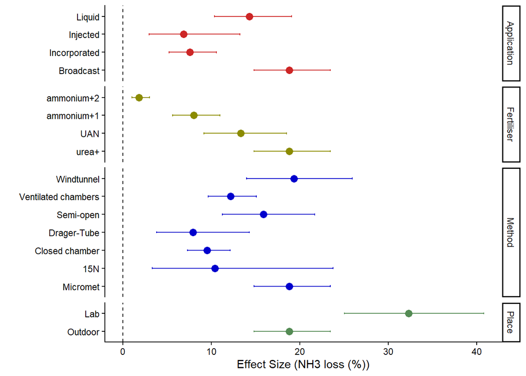

Model A_Base explains 28.27 % of the variation in the data (conditional R2), with the fixed effects explaining 13.45 % (marginal R2). The R2-values for linear mixed effects model were calculated according to Nagakawa & Schielzeth (2013).

## Model A_Application rate

The sole explanatory variable in Model A_Application rate was application rate (kg/ha).

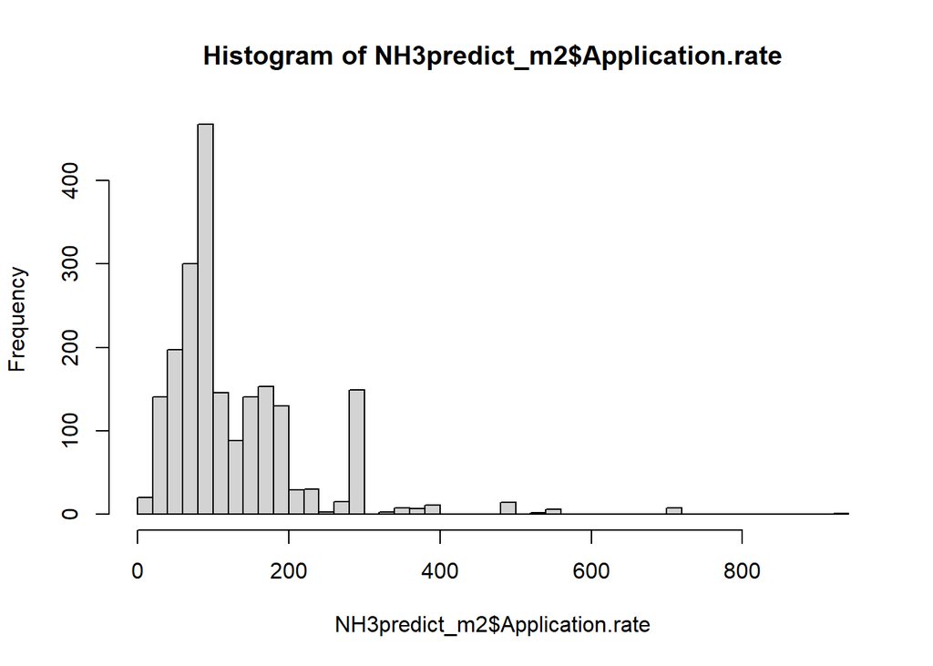

The model as it was applied can be seen below:

```r
# Model
m2_lm <- lm(sign(NH3loss) * abs(NH3loss) ^ (1/3) ~ Application.rate + offset(M1_fit),
            weights=Weight,
            data=NH3predict_m2)
```

The model assumptions can be seen below:

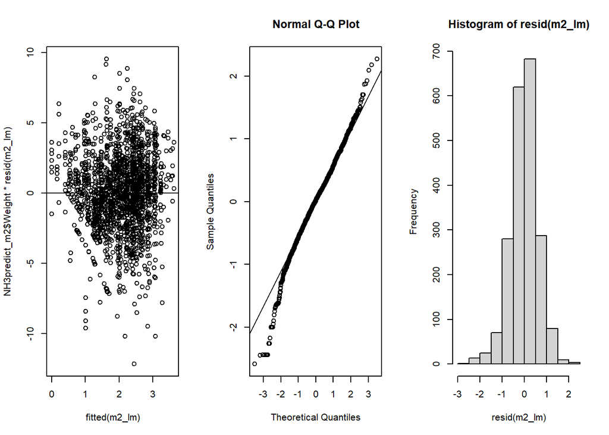

Application rate did not significantly explain variation in NH3-emissions (F(1, 2067) =0.12, p = 0.734). There was a statistically non-significant positive trend between Application rate and NH3-emissions ($\beta$+/-SE = 5^{-5} +/- 1.4^{-4}).

Full model output can be seen below:

```
##
## Call:
## lm(formula = sign(NH3loss) * abs(NH3loss)^(1/3) ~ Application.rate +
##     offset(M1_fit), data = NH3predict_m2, weights = Weight)
##
## Weighted Residuals:
##     Min      1Q  Median      3Q     Max
## -5.4598 -0.7857  0.0312  0.8146  4.6529
##
## Coefficients:
##                    Estimate Std. Error t value Pr(>|t|)
## (Intercept)      -0.0092264  0.0235097  -0.392    0.695
## Application.rate  0.0000484  0.0001425   0.340    0.734
##
## Residual standard error: 1.304 on 2067 degrees of freedom
## Multiple R-squared:  5.584e-05,  Adjusted R-squared:  -0.0004279
## F-statistic: 0.1154 on 1 and 2067 DF,  p-value: 0.7341
```

Application rate explains -0.04 % of residual variation in NH3-emissions (adjusted R-squared). (Note: Adjusted R-squared is manually adjusted to incorporate the offset-variable, and thus not consistent with the adjusted R-squared from the above model output.)

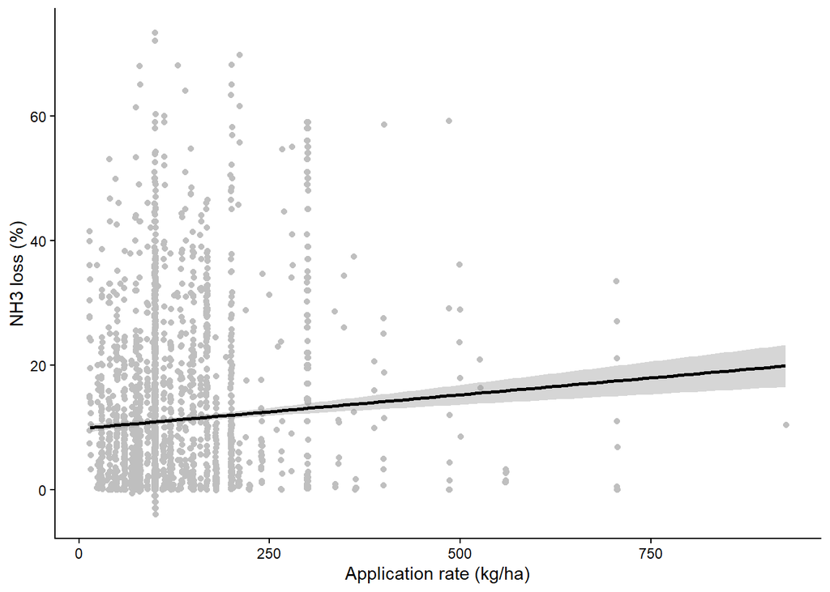

## Model A_Soil pH

Soil pH was binarised into categories, where soils with pH>7.0 were categorised as chalky, and ph<=7.0 as normal. The number of observations in each group and their frequency distribution can be seen below.

```
##   pH_cat    N
## 1 normal 1509
## 2 chalky  991
```

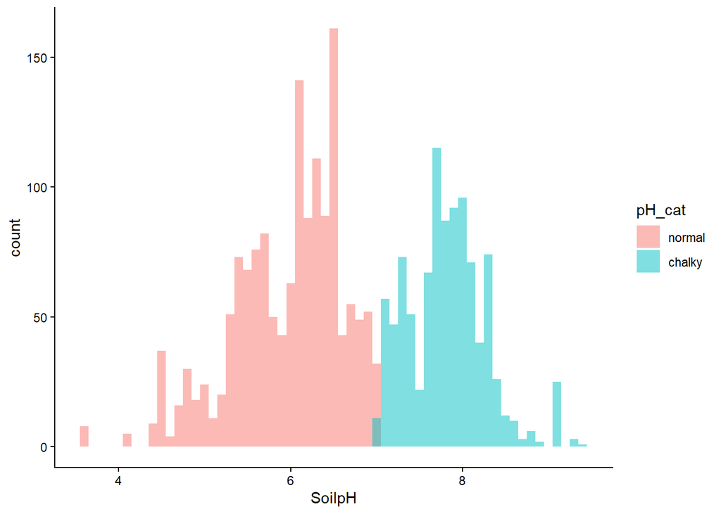

Model A_Soil pH followed the structure of Model A_Application rate. We added Soil pH, Fertiliser type, and the interaction between the two as fixed factors. In this model, Fertiliser types were used to identify differences between pH-categories, not to analyse the effect of Fertiliser on its own - the offset of Model A_Base removes the variation explained by Fertilisers otherwise.

```r
# Model
m3_lm <- lm(sign(NH3loss) * abs(NH3loss) ^ (1/3) ~ Fertiliser * pH_cat + offset(M1_fit),
            weights=Weight,
            data=NH3predict_m3)
```

The heteroscedasticity and normality of errors were as below:

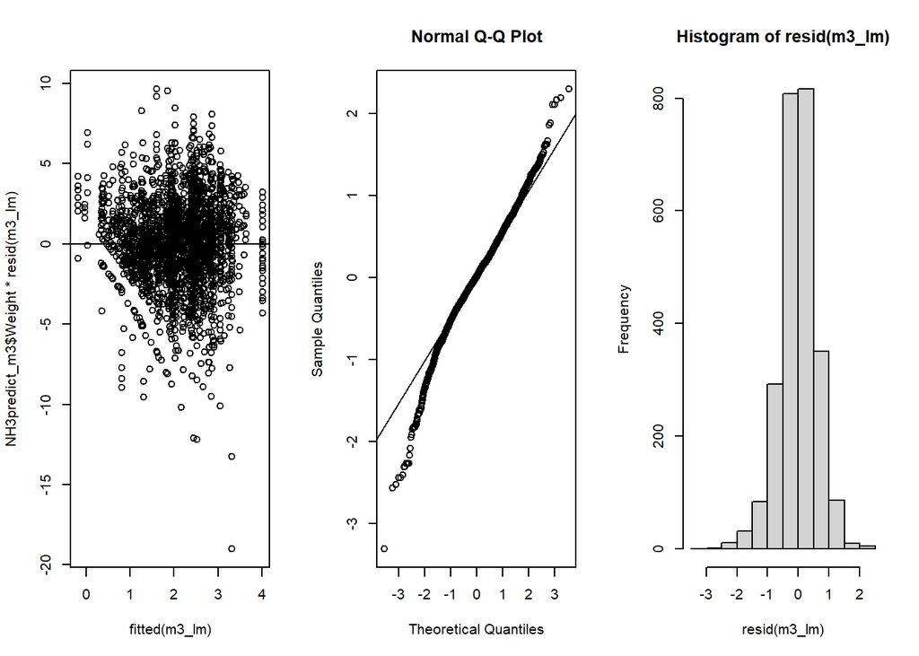

The effect of soil pH on NH3-emissions was dependent on the Fertiliser types (F(3, 2492) =29.53, p <0.001). Soil pH also had an independent effect on NH3 emissions (F(1, 2492) =29.41, p <0.001).

Full anova-table can be seen below:

```
## Analysis of Variance Table
##
## Response: sign(NH3loss) * abs(NH3loss)^(1/3)
##                     Df Sum Sq Mean Sq F value    Pr(>F)
## Fertiliser           3    0.0   0.004  0.0026    0.9998
## pH_cat               1   49.0  48.956 29.4077 6.429e-08 ***
## Fertiliser:pH_cat    3  147.5  49.165 29.5332 < 2.2e-16 ***
## Residuals         2492 4148.6   1.665
## ---
## Signif. codes:  0 '***' 0.001 '**' 0.01 '*' 0.05 '.' 0.1 ' ' 1
```

Full model output can be seen below:

```
##
## Call:
## lm(formula = sign(NH3loss) * abs(NH3loss)^(1/3) ~ Fertiliser *
##     pH_cat + offset(M1_fit), data = NH3predict_m3, weights = Weight)
##
## Weighted Residuals:
##     Min      1Q  Median      3Q     Max
## -7.9332 -0.6976  0.0276  0.8065  4.7079
##
## Coefficients:
##                                    Estimate Std. Error t value Pr(>|t|)
## (Intercept)                        0.007308   0.018050   0.405   0.6856
## FertiliserUAN                     -0.086427   0.071785  -1.204   0.2287
## Fertiliserammonium+1              -0.324408   0.053461  -6.068 1.49e-09 ***
## Fertiliserammonium+2              -0.192804   0.046786  -4.121 3.90e-05 ***
## pH_catchalky                      -0.019870   0.029937  -0.664   0.5069
## FertiliserUAN:pH_catchalky         0.253247   0.121508   2.084   0.0372 *
## Fertiliserammonium+1:pH_catchalky  0.543488   0.071480   7.603 4.06e-14 ***
## Fertiliserammonium+2:pH_catchalky  0.504965   0.075775   6.664 3.27e-11 ***
## ---
## Signif. codes:  0 '***' 0.001 '**' 0.01 '*' 0.05 '.' 0.1 ' ' 1
##
## Residual standard error: 1.29 on 2492 degrees of freedom
## Multiple R-squared:  0.04522,    Adjusted R-squared:  0.04253
## F-statistic: 16.86 on 7 and 2492 DF,  p-value: < 2.2e-16
```

The model explained 4.22 % of the residual variation in NH3-loss.

### Combining A_Base and A_Soil pH

For acquiring estimates for Soil pH in different fertiliser types at the same time, and same scale as the base-model, we added Soil pH and the interaction between pH and FertiliserType into the initial model. Please note this model has less data than Model A_Base, and as it includes new parameters, the estimates change slightly.

The effect sizes (marginal means) for the interaction can be seen below. The effect sizes are given at the back-transformed scale (NH3-loss %), parametrised to Fertiliser=urea+, Application=Broadcast, Method=Micromet, Place=outdoor, pH=normal.

```
##                Factor               Level     Effect         SE         df
## 1          Fertiliser               urea+ 18.6100078 0.10631740  1715.0477
## 2          Fertiliser                 UAN 14.1871183 0.14417582  3566.0824
## 3          Fertiliser          ammonium+1  8.0787757 0.11569160  2185.5872
## 4          Fertiliser          ammonium+2  2.3252790 0.11467127  2196.2294
## 5         Application           Broadcast 18.6100078 0.10631740  1715.0477
## 6         Application        Incorporated  7.0290112 0.11990924  2393.3074
## 7         Application            Injected  7.2799567 0.23591370 16656.2093
## 8         Application              Liquid 13.7200650 0.12696758  2249.6707
## 9              Method            Micromet 18.6100078 0.10631740  1715.0477
## 10             Method                 15N  9.3235872 0.34395787 24627.6594
## 11             Method      Closed chamber  9.5221832 0.08928607   583.9193
## 12             Method         Drager-Tube  7.6435377 0.20833646   222.2869
## 13             Method           Semi-open 17.2080318 0.13393112   742.2909
## 14             Method Ventilated chambers 12.2546596 0.08620986   961.0417
```

[output cut: 41 more lines]

The same effect sizes (and their 95% confidence interval) are shown below:

```
## `height` was translated to `width`.
```

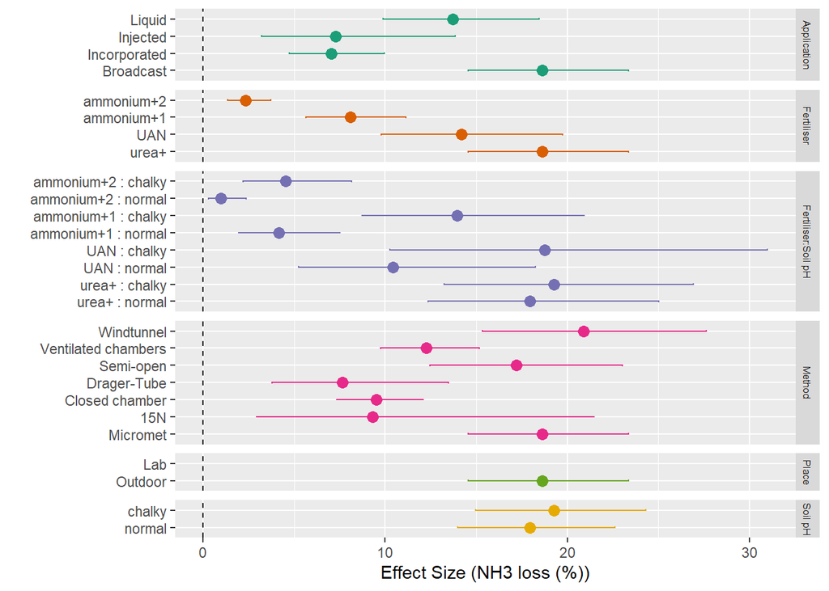

## Model A_Soil clay content

In Model A_Soil clay content, we explored the effect of Soil clay content (%) on NH3-loss (%).

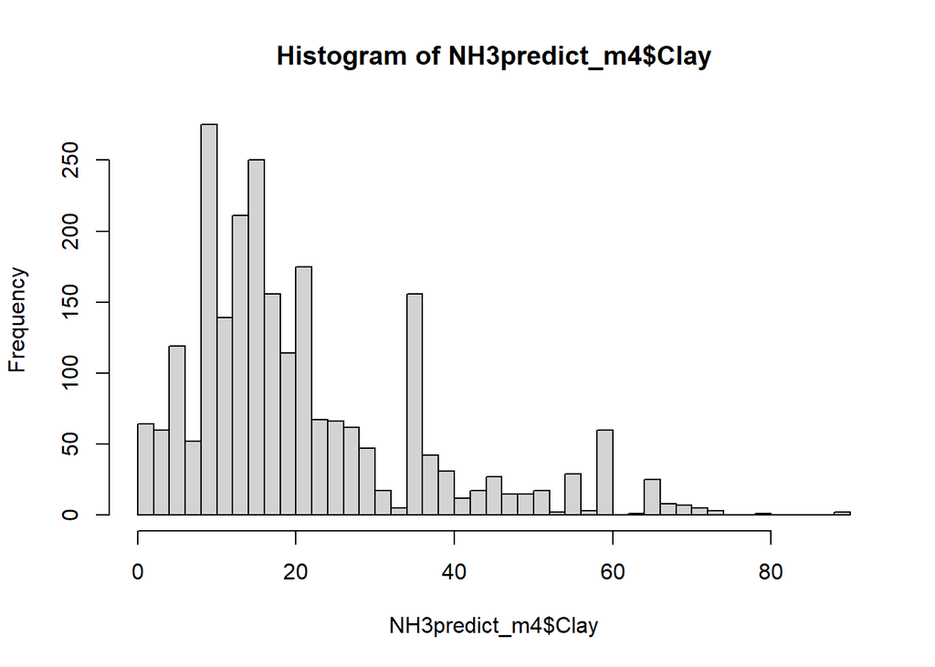

We used Soil clay content (%) as a continuous covariate and the sole explanatory variable in the model.

```r
# Model
m4_lm <- lm(sign(NH3loss) * abs(NH3loss) ^ (1/3) ~ Clay + offset(M1_fit),
            weights=Weight,
            data=NH3predict_m4)
```

The model assumptions (heteroscedasticity and normality of errors):

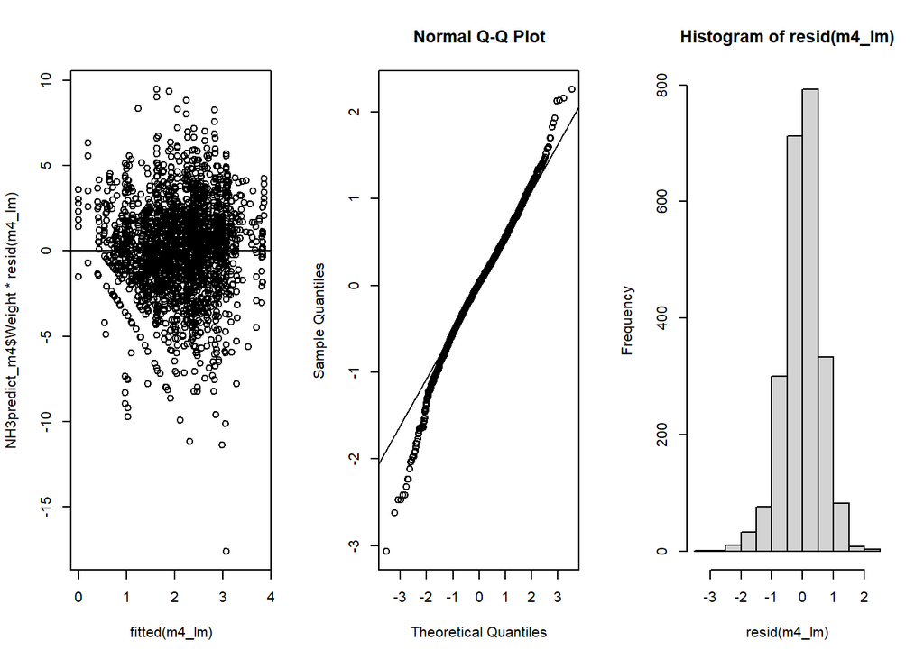

Soil clay content (%) affected NH3-loss (%) negatively ($\beta$+/-SE = -0.00247 +/- 8.2^{-4}, F(1, 2355) =9.16, p = 0.003).

Full model output can be seen below:

```
##
## Call:
## lm(formula = sign(NH3loss) * abs(NH3loss)^(1/3) ~ Clay + offset(M1_fit),
##     data = NH3predict_m4, weights = Weight)
##
## Weighted Residuals:
##     Min      1Q  Median      3Q     Max
## -7.3570 -0.7569  0.0576  0.8083  4.6249
##
## Coefficients:
##               Estimate Std. Error t value Pr(>|t|)
## (Intercept)  0.0526740  0.0212372   2.480   0.0132 *
## Clay        -0.0024705  0.0008163  -3.027   0.0025 **
## ---
## Signif. codes:  0 '***' 0.001 '**' 0.01 '*' 0.05 '.' 0.1 ' ' 1
##
## Residual standard error: 1.298 on 2355 degrees of freedom
## Multiple R-squared:  0.003875,   Adjusted R-squared:  0.003452
## F-statistic:  9.16 on 1 and 2355 DF,  p-value: 0.0025
```

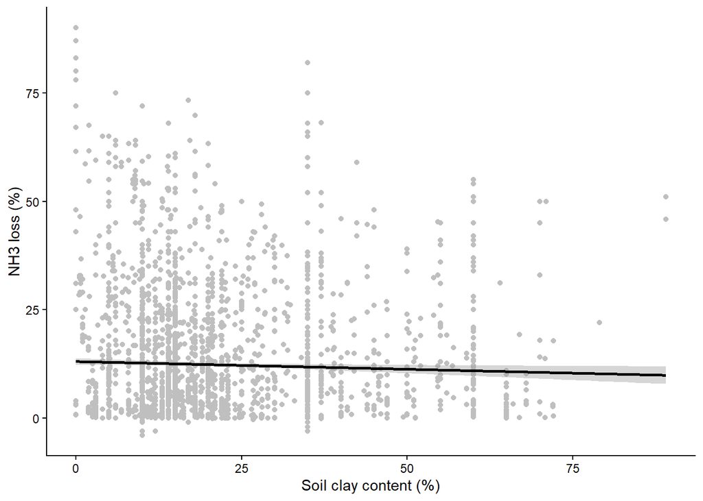

Test to see if a exponential function provides a better fit for the Clay data. The fit and parameters c and d were fitted a non-linear least-squares model.

```
##
## Formula: NH3loss ~ c * exp(d * (Clay))
##
## Parameters:
##    Estimate Std. Error t value Pr(>|t|)
## c 16.195873   0.605880  26.731  < 2e-16 ***
## d -0.004563   0.001584  -2.882  0.00399 **
## ---
## Signif. codes:  0 '***' 0.001 '**' 0.01 '*' 0.05 '.' 0.1 ' ' 1
##
## Residual standard error: 15.52 on 2355 degrees of freedom
##
## Number of iterations to convergence: 15
## Achieved convergence tolerance: 1.49e-08
```

The fitted relationship is as below:

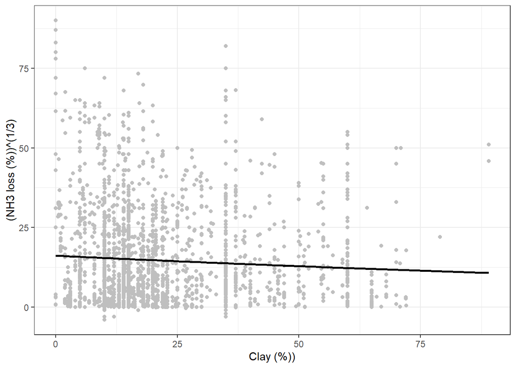

```r
# Transforming the Clay values to exp-scale
NH3predict_m4$Clay.exp <- coef(MR_nls_clay)[[1]]*exp(coef(MR_nls_clay)[[2]]*NH3predict_m4$Clay)
```

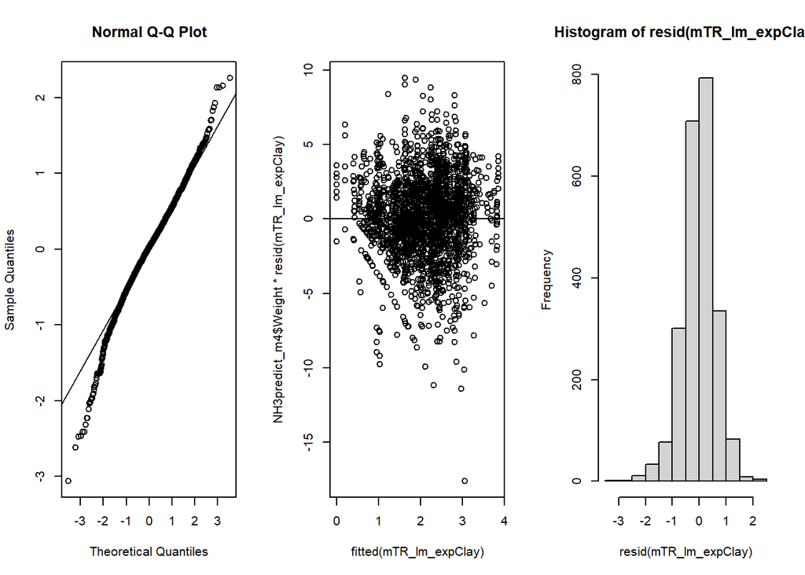

```
##
## Call:
## lm(formula = sign(NH3loss) * abs(NH3loss)^(1/3) ~ Clay.exp +
##     offset(M1_fit), data = NH3predict_m4, weights = Weight)
##
## Weighted Residuals:
##     Min      1Q  Median      3Q     Max
## -7.3495 -0.7596  0.0578  0.8083  4.6213
##
## Coefficients:
##             Estimate Std. Error t value Pr(>|t|)
## (Intercept) -0.58877    0.18762  -3.138  0.00172 **
## Clay.exp     0.03997    0.01270   3.147  0.00167 **
## ---
## Signif. codes:  0 '***' 0.001 '**' 0.01 '*' 0.05 '.' 0.1 ' ' 1
##
## Residual standard error: 1.298 on 2355 degrees of freedom
## Multiple R-squared:  0.004188,   Adjusted R-squared:  0.003765
## F-statistic: 9.904 on 1 and 2355 DF,  p-value: 0.00167
```

## Model A_Soil organic carbon

Soil organic carbon (g/kg) was modeled as a continuous variable. Most soils in the data were mineral (with a cutoff of 120 g/kg SOC), with only 3 organic soils in the dataset.

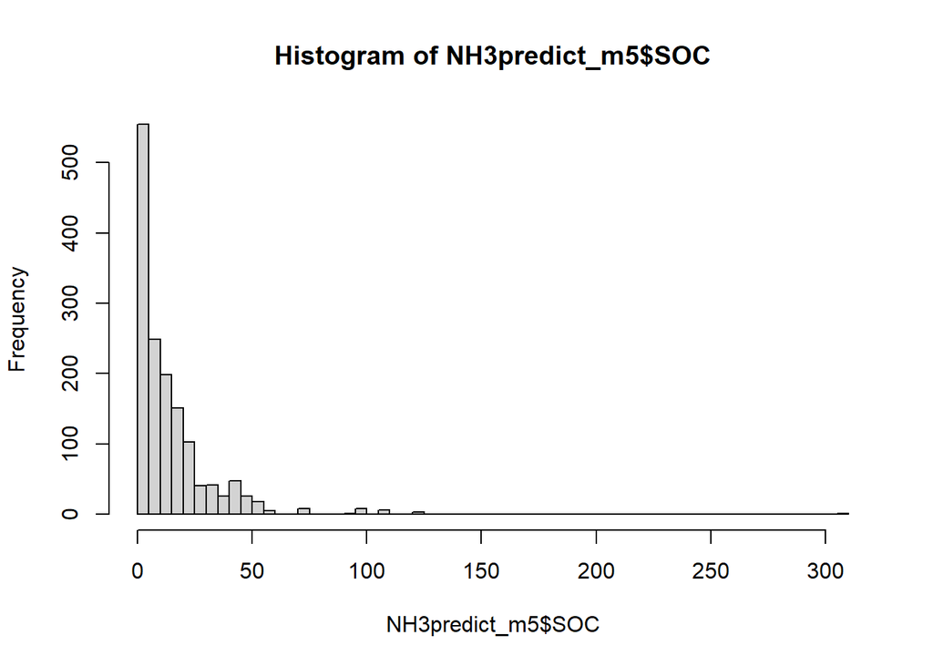

We used Soil organic carbon (g/kg) as a sole continuous covariate in the model.

```r
# Model
m5_lm <- lm(sign(NH3loss) * abs(NH3loss) ^ (1/3) ~ SOC + offset(M1_fit),
            weights=Weight,
            data=NH3predict_m5)
```

The model assumptions (heteroscedasticity and normality of errors):

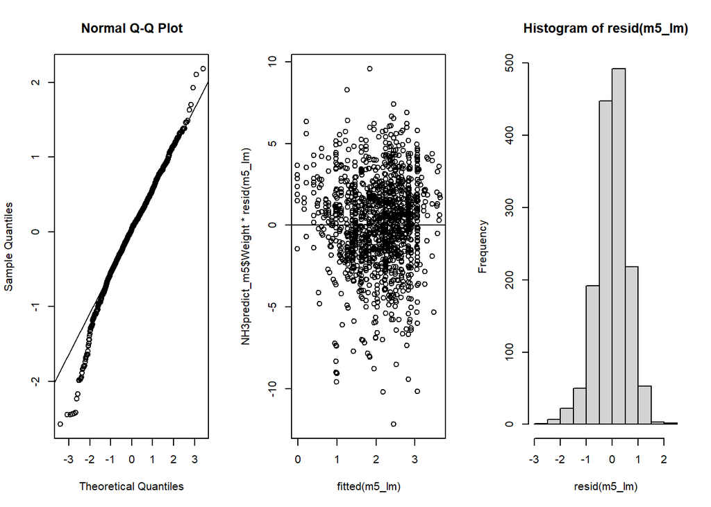

There was no effect of Soil organic carbon (g/kg) on NH3 loss (F(1, 1486) =0.51, p = 0.474).

Full model output can be seen below:

```
##
## Call:
## lm(formula = sign(NH3loss) * abs(NH3loss)^(1/3) ~ SOC + offset(M1_fit),
##     data = NH3predict_m5, weights = Weight)
##
## Weighted Residuals:
##     Min      1Q  Median      3Q     Max
## -5.4648 -0.7520  0.0797  0.8067  4.5678
##
## Coefficients:
##               Estimate Std. Error t value Pr(>|t|)
## (Intercept)  0.0008805  0.0198186   0.044    0.965
## SOC         -0.0006156  0.0008600  -0.716    0.474
##
## Residual standard error: 1.303 on 1486 degrees of freedom
## Multiple R-squared:  0.0003447,  Adjusted R-squared:  -0.000328
## F-statistic: 0.5124 on 1 and 1486 DF,  p-value: 0.4742
```

Adjusted R2-value of the model was 0, and multiple R2 was 3.45^{-4}. The negative adjusted R2-value indicates that the amount of variation accounted for by Soil organic carbon is negligible. In practice, soil organic carbon explains no variation in the data.

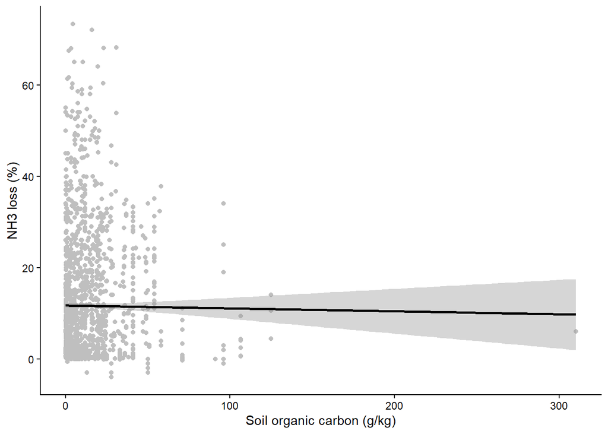

## Model A_Cover

```
##    Cover    N
## 1   None 1516
## 2 Arable  730
## 3  Grass  332
## 4  Other   18
```

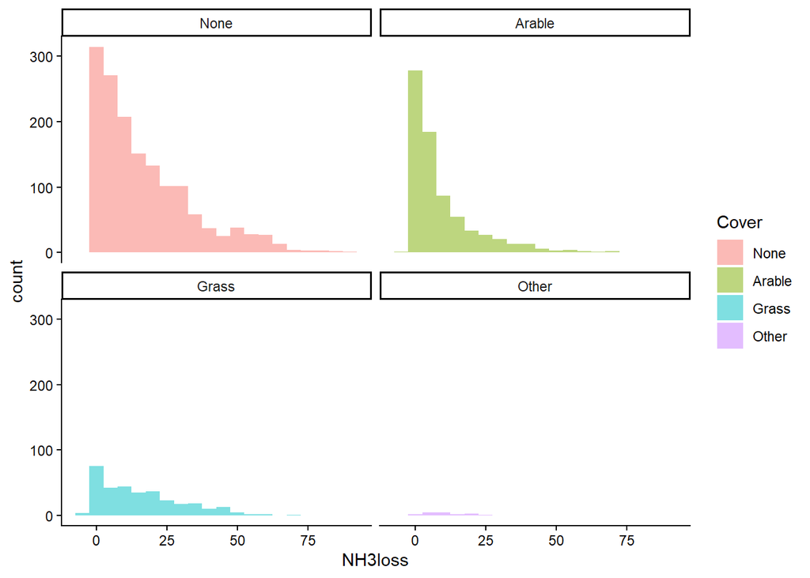

We added Cover as a fixed factor and a sole explanatory variable in the model.

```r
# Model
m6_lm <- lm(sign(NH3loss) * abs(NH3loss) ^ (1/3) ~ Cover + offset(M1_fit),
            weights=Weight,
            data=NH3predict_m6)
```

The model assumptions (heteroscedasticity and normality of errors):

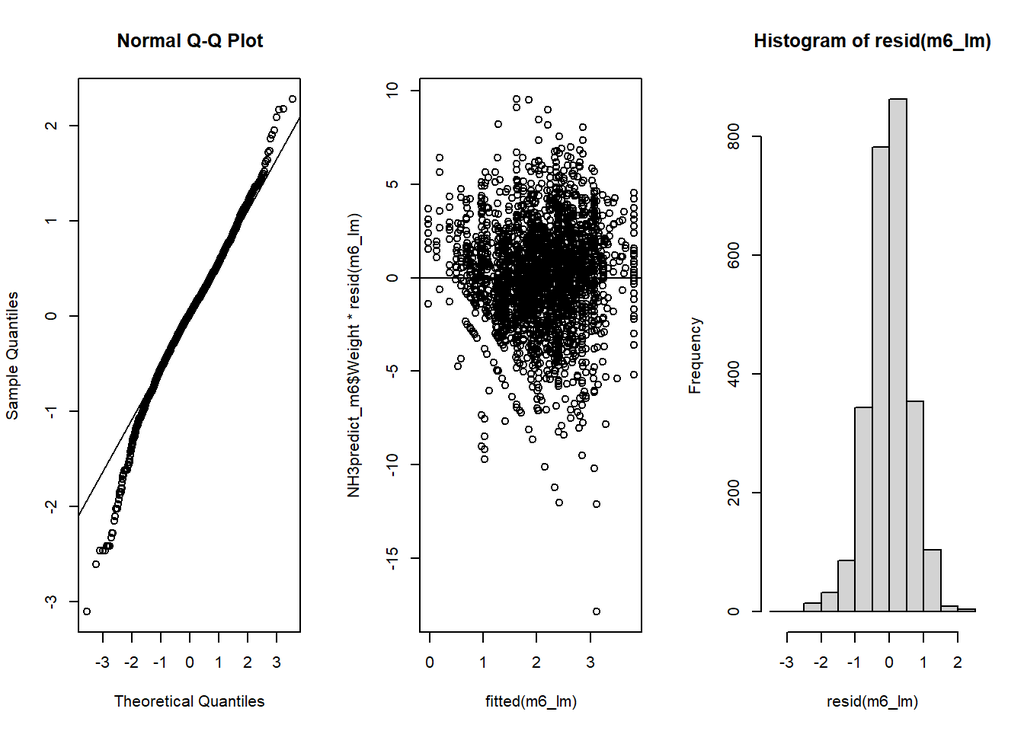

Full model output can be seen below:

```
##
## Call:
## lm(formula = sign(NH3loss) * abs(NH3loss)^(1/3) ~ Cover + offset(M1_fit),
##     data = NH3predict_m6, weights = Weight)
##
## Weighted Residuals:
##     Min      1Q  Median      3Q     Max
## -7.4575 -0.7637  0.0435  0.8133  4.6656
##
## Coefficients:
##              Estimate Std. Error t value Pr(>|t|)
## (Intercept)  0.008109   0.015327   0.529    0.597
## CoverArable -0.036038   0.027853  -1.294    0.196
## CoverGrass   0.011895   0.036461   0.326    0.744
## CoverOther  -0.031987   0.144471  -0.221    0.825
##
## Residual standard error: 1.309 on 2592 degrees of freedom
## Multiple R-squared:  0.0008154,  Adjusted R-squared:  -0.000341
## F-statistic: 0.7051 on 3 and 2592 DF,  p-value: 0.5489
```

Adjusted R2-value of the model was -3.4^{-4}, and multiple R2 was 8.2^{-4}. The negative adjusted R2-value indicates that the amount of variation accounted for by Cover crops is negligible. In practice, cover crops explain no variation in the data.

```
##    Cover   emmean         SE   df lower.CL upper.CL
## 1   None 2.072015 0.01532705 2592 2.041960 2.102069
## 2 Arable 2.035977 0.02325702 2592 1.990372 2.081581
## 3  Grass 2.083910 0.03308250 2592 2.019039 2.148780
## 4  Other 2.040027 0.14365570 2592 1.758336 2.321719
```

```
## `height` was translated to `width`.
```

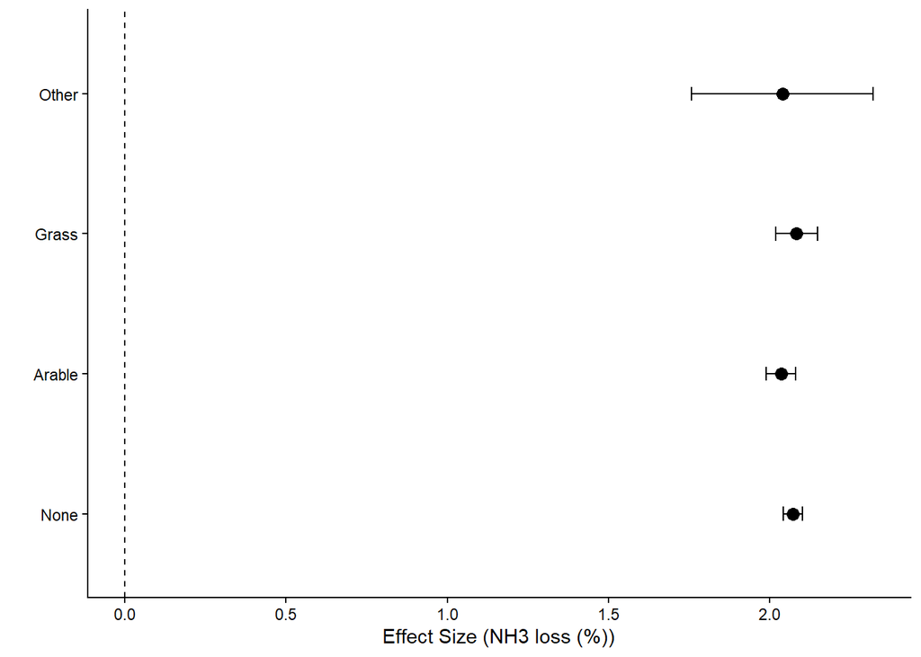